Laboratorio 3 - Respuestas a Tarea 3 Juvenal Campos y Sebastián Garrido 3/23/2020

# Librerías y opciones.

```r
# Librerias y opciones
library(pacman)
p_load(moderndive, # Para hacer el muestreo
       tidyverse)  # Para usar la %>% y los verbos dplyr

# Para mostrar más números decimales en las tibbles.
options(pillar.sigfig = 7)
```

# Ejercicio 1

En clase analizamos si la **media** y la **mediana** eran estimadores insesgados del promedio de una población **normal**.

En este ejercicio harás lo mismo, pero para una distribución **beta**. En [esta](https://onlinelibrary.wiley.com/doi/pdf/10.1002/9781119197096.app03) (p. 906) y [esta otra](http://varianceexplained.org/statistics/beta_distribution_and_baseball/)[^1] ligas puedes aprender más sobre esta distribución.

1. Usa el siguiente código para construir la distribución:

```r
set.seed(1)
datos <- tibble(valores =
                  rbeta(n = 1e6,
                        shape1 = 6,
                        shape2 = 1))
```

2. Grafica la distribución. ¿Es simétrica? Si la respuesta es no, ¿qué tipo de sesgo tiene?

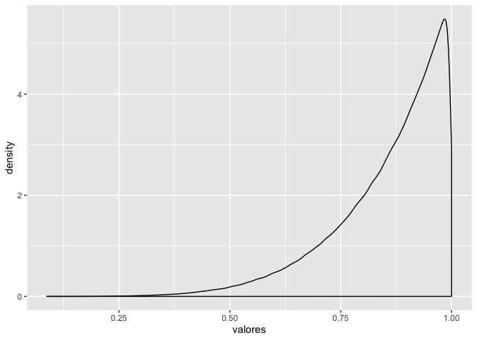

```r
datos %>%
  ggplot(aes(valores)) +
  geom_density()
```

```r
# Sesgo izquierdo
```

3. Calcula la media y mediana poblacional

```r
est_pob <-
  datos %>%
  summarise(media_pob = mean(valores),
            mediana_pob = median(valores))

est_pob
```

```
## # A tibble: 1 x 2
##   media_pob mediana_pob
##       <dbl>       <dbl>
## 1 0.8572228   0.8910398
```

#### Escenario 1

- Planta un `set.seed(1)` y toma **1,000** muestras sin remplazo, cada una de tamaño **5**.
- Calcula la media y mediana de cada muestra. Guarda los cálculos de las medias muestrales en una variable llamada `media_muestral` y los de las medianas en `mediana_muestral`.
- Calcula el promedio de `media_muestral` y `mediana_muestral`. Guarda los resultados en `promedio_medias_muestrales` y `promedio_medianas_muestrales`.

```r
set.seed(1)
datos %>%
  rep_sample_n(size = 5, reps = 1000) %>%
  summarise(media_muestral = mean(valores),
            mediana_muestral = median(valores)) %>%
  summarise(promedio_media_muestral =
              mean(media_muestral),
            promedio_mediana_muestral =
              mean(mediana_muestral)) %>%
  gather(key = variable,
         value = valor)
```

```
## # A tibble: 2 x 2
##   variable                      valor
##   <chr>                         <dbl>
## 1 promedio_media_muestral   0.8576992
## 2 promedio_mediana_muestral 0.8820205
```

Por favor responde:

1. ¿El promedio de alguno de los estimadores es igual a su respectivo parámetro poblacional?

**(Respuesta válida para todas las demás preguntas similares).**

> Si trabajamos con poquitos decimales, pudiera llegar a parecer que si, pero la probabilidad de que la estimación sea igual al parámetro poblacional es igual a cero (ya que el resultado de la estimación también es una variable aleatoria contínua, y la probabilidad de que una variable aleatoria contínua sea igual a un número exacto es siempre igual a cero).
2. Si es así, ¿cuál? Si no es así, ¿cuál está más cerca y por cuánto?

> Ninguna estimación es igual al parámetro poblacional de la media, sin embargo, en el código siguiente vamos a estimar la diferencia que hay entre la estimación y el parámetro poblacional.

**OJO**: antes de responder estas preguntas, asegúrate de haber corrido primero `set.seed(1)` y después el chunk con tus cálculos. De lo contrario no podremos replicar tus datos 😢.

```r
set.seed(1)
datos %>%
  rep_sample_n(size = 5, reps = 1000) %>%
  summarise(media_muestral = mean(valores),
            mediana_muestral = median(valores)) %>%
  summarise(promedio_media_muestral =
              mean(media_muestral),
            promedio_mediana_muestral =
              mean(mediana_muestral)) %>%
  gather(key = variable,
         value = valor) %>%
  mutate(dif_absoluta_media =
           ifelse(variable == "promedio_media_muestral",
                  yes = abs(est_pob$media_pob - valor),
                  no = abs(est_pob$mediana_pob - valor)))
```

```
## # A tibble: 2 x 3
##   variable                      valor dif_absoluta_media
##   <chr>                         <dbl>              <dbl>
## 1 promedio_media_muestral   0.8576992       0.0004763692
## 2 promedio_mediana_muestral 0.8820205       0.009019281
```

#### Escenario 2

Repite los pasos del Escenario 1, pero ahora aumenta el tamaño de cada muestra a **50**.

Por favor responde:

1. ¿El promedio de alguno de los estimadores es igual a su respectivo parámetro poblacional?

> Si trabajamos con poquitos decimales, pudiera llegar a parecer que si, pero la probabilidad de que la estimación sea igual al parámetro poblacional es igual a cero (ya que el resultado de la estimación también es una variable aleatoria contínua, y la probabilidad de que una variable aleatoria contínua sea igual a un número exacto es siempre igual a cero).
2. Si es así, ¿cuál? Si no es así, ¿cuál está más cerca y por cuánto? > Ninguna estimación es igual al parámetro poblacional de la media, sin embargo, en el código siguiente vamos a estimar la diferencia que hay entre la estimación y el parámetro poblacional.

```r
set.seed(1)
datos %>%
  rep_sample_n(size = 50, reps = 1000) %>%
  summarise(media_muestral = mean(valores),
            mediana_muestral = median(valores)) %>%
  summarise(promedio_media_muestral = mean(media_muestral),
            promedio_mediana_muestral = mean(mediana_muestral)) %>%
  gather(key = variable,
         value = valor) %>%
  mutate(dif_absoluta_media =
           ifelse(variable == "promedio_media_muestral",
                  yes = abs(est_pob$media_pob - valor),
                  no = abs(est_pob$mediana_pob - valor)))
```

```
## # A tibble: 2 x 3
##   variable                      valor dif_absoluta_media
##   <chr>                         <dbl>              <dbl>
## 1 promedio_media_muestral   0.8573599       0.0001370857
## 2 promedio_mediana_muestral 0.8904710       0.0005687476
```

#### Escenario 3

Repite los pasos del Escenario 1, pero ahora aumenta el tamaño de cada muestra a **100**.

Por favor responde:

1. ¿El promedio de alguno de los estimadores es igual a su respectivo parámetro poblacional?

> Si trabajamos con poquitos decimales, pudiera llegar a parecer que si, pero la probabilidad de que la estimación sea igual al parámetro poblacional es igual a cero (ya que el resultado de la estimación también es una variable aleatoria contínua, y la probabilidad de que una variable aleatoria contínua sea igual a un número exacto es siempre igual a cero).
2. Si es así, ¿cuál? Si no es así, ¿cuál está más cerca y por cuánto? > Ninguna estimación es igual al parámetro poblacional de la media, sin embargo, en el código siguiente vamos a estimar la diferencia que hay entre la estimación y el parámetro poblacional.

```r
set.seed(1)
datos %>%
  rep_sample_n(size = 100, reps = 1000) %>%
  summarise(media_muestral = mean(valores),
            mediana_muestral = median(valores)) %>%
  summarise(promedio_media_muestral = mean(media_muestral),
            promedio_mediana_muestral = mean(mediana_muestral)) %>%
  gather(key = variable,
         value = valor) %>%
  mutate(dif_absoluta_media =
           ifelse(variable == "promedio_media_muestral",
                  yes = abs(est_pob$media_pob - valor),
                  no = abs(est_pob$mediana_pob - valor)))
```

```
## # A tibble: 2 x 3
##   variable                      valor dif_absoluta_media
##   <chr>                         <dbl>              <dbl>
## 1 promedio_media_muestral   0.8572043      0.00001850602
## 2 promedio_mediana_muestral 0.8902756      0.0007641925
```

#### Escenario 4

Repite los pasos del Escenario 1, pero ahora cambia el **número de muestras** de **1,000** a **10,000**. El tamaño de cada una seguirá siendo de **5**.

Por favor responde:

1. ¿El promedio de alguno de los estimadores es igual a su respectivo parámetro poblacional?

> Si trabajamos con poquitos decimales, pudiera llegar a parecer que si, pero la probabilidad de que la estimación sea igual al parámetro poblacional es igual a cero (ya que el resultado de la estimación también es una variable aleatoria contínua, y la probabilidad de que una variable aleatoria contínua sea igual a un número exacto es siempre igual a cero).
2. Si es así, ¿cuál? Si no es así, ¿cuál está más cerca y por cuánto?

> Ninguna estimación es igual al parámetro poblacional de la media, sin embargo, en el código siguiente vamos a estimar la diferencia que hay entre la estimación y el parámetro poblacional.

```r
set.seed(1)
datos %>%
  rep_sample_n(size = 5, reps = 10000) %>%
  summarise(media_muestral = mean(valores),
            mediana_muestral = median(valores)) %>%
  summarise(promedio_media_muestral = mean(media_muestral),
            promedio_mediana_muestral = mean(mediana_muestral)) %>%
  gather(key = variable,
         value = valor) %>%
  mutate(dif_absoluta_media =
           ifelse(variable == "promedio_media_muestral",
                  yes = abs(est_pob$media_pob - valor),
                  no = abs(est_pob$mediana_pob - valor)))
```

```
## # A tibble: 2 x 3
##   variable                      valor dif_absoluta_media
##   <chr>                         <dbl>              <dbl>
## 1 promedio_media_muestral   0.8573634       0.0001406020
## 2 promedio_mediana_muestral 0.8802809       0.01075889
```

#### Reflexiones generales

Por favor piensa y responde las siguientes preguntas:

- ¿Qué pasa con el estimador de la media y la mediana conforme aumenta el **tamaño de cada muestra**? (comparación de escenarios 2 y 3 vs. 1)

# Ejercicio 2

A continuación verás el código que utilicé en clase para ilustrar qué significa el nivel de confianza de un intervalo de confianza. Por favor cópialo y ejecútalo en el script de tu tarea:

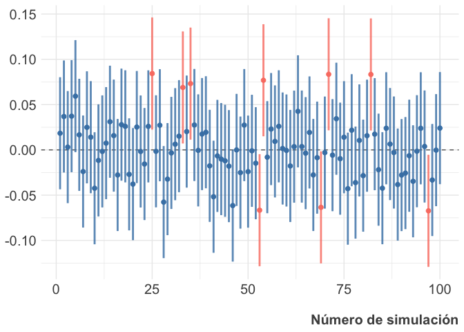

```r
# Paso 1 - Generar los datos poblacionales
set.seed(33)
datos <-
  tibble(valores = rnorm(n = 1e6, mean = 0, sd = 1))

# Paso 2 - Definir el tamaño de cada muestra y el número de muestras
tamaño_muestra <- 1000
numero_muestras <- 100

# Paso 3 - Calcular el error estándar de la media muestral, asumiendo
# que el tamaño de la muestra es 1,000
error_est_con_datos_pob <- sd(datos$valores)/sqrt(tamaño_muestra)

# Paso 4 - Calcular la media de cada muestra y construye su respectivo
# intervalo de confianza usando el error estándar que calculamos
# en el paso 3
set.seed(4)
datos %>%
  rep_sample_n(size = tamaño_muestra,
               replace = T,
               reps = numero_muestras) %>%
  summarise(media_muestral = mean(valores),
            lim_sup = media_muestral + 1.96*error_est_con_datos_pob,
            lim_inf = media_muestral - 1.96*error_est_con_datos_pob) %>%
  mutate(color_intervalos = ifelse(lim_sup < 0 | lim_inf > 0,
                                   yes = "salmon",
                                   no = "steelblue")) %>%
  ggplot(aes(x = replicate,
             y = media_muestral,
             color = color_intervalos)) +
  geom_hline(yintercept = 0,
             color = "grey40",
             linetype = 2,
             size = 0.5) +
  geom_point(size = 2) +
  geom_errorbar(aes(ymin = lim_inf,
                    ymax = lim_sup),
                width = 0.01,
                alpha = 0.82,
                size = 1) +
  scale_color_manual(values =
                       c("salmon", "steelblue")) +
  labs(x = "\nNúmero de simulación") +
  theme_minimal() +
  theme(axis.title.x =
          element_text(hjust = 1, face = "bold",
                       color = "grey30", size = 15),
        axis.title.y = element_blank(),
        axis.text = element_text(size = 15),
        legend.position = "none")
```

1. Por favor explica qué es lo que estoy haciendo en cada paso. Para el paso 3 basta con que expliques hasta el renglón en donde uso `scale_color_manual()`.

**Paso 1** Generar los datos poblacionales.

```r
# Paso 1 - Generar los datos poblacionales
set.seed(33) # Fijamos semilla para que todo sea reproducible

# Generamos el tibble poblacional, que consiste en una variable
## aleatoria que distribuye de manera normal con parámetros 0
## y desviación estándar de 1
datos <-
  tibble(valores =
           rnorm(n = 1e6, mean = 0, sd = 1))
```

**Paso 2** Definir el tamaño de cada muestra y el número de muestras.

```r
# Paso 2 - Definir el tamaño de cada muestra y el número de muestras
tamaño_muestra <- 1000 # Observaciones por muestra aleatoria
numero_muestras <- 100 # Numero de muestras
```

**Paso 3** Calcular el error estándar de la media muestral, asumiendo que el tamaño de la muestra es 1,000.

```r
# Paso 3 - Calcular el error estándar de la media muestral, asumiendo
# que el tamaño de la muestra es 1,000

# Calculamos el error estándar de la muestra con la formula normal.
error_est_con_datos_pob <- sd(datos$valores)/sqrt(tamaño_muestra)
```

**Paso 4** Calcular la media de cada muestra y construye su respectivo intervalo de confianza usando el error estándar que calculamos en el paso 3.

```r
# Paso 4 - Calcular la media de cada muestra y construye su respectivo # intervalo de confianza usando el error estándar que calculamos
# en el paso 3

set.seed(4) # Fijamos semilla de reproducibilidad

# Generamos las muestras:
datos %>%
  rep_sample_n(size = tamaño_muestra,
               replace = T,
               reps = numero_muestras) %>%
# Calculamos la estimación muestral y los límites del I.C.
  summarise(media_muestral = mean(valores),
            lim_sup = media_muestral + 1.96*error_est_con_datos_pob,
            lim_inf = media_muestral - 1.96*error_est_con_datos_pob) %>%
# Obtenemos las observaciones que caen fuera del I.C., y
##  les asignamos un color característico
  mutate(color_intervalos = ifelse(lim_sup < 0 | lim_inf > 0,
                                   "salmon", "steelblue")) %>%
# Generamos la gráfica; declaramos los canales
  ggplot(aes(x = replicate, y = media_muestral, color = color_intervalos)) +
# Generamos una línea recta que pasa por el 0 - EL parámetro
##  poblacional
  geom_hline(yintercept = 0, color = "grey40", linetype = 2, size = 0.5) +
# Generamos una gráfica de puntos que marquen la media muestral
  geom_point(size = 2) +
# Generamos un errorbar; una gráfica que genera segmentos
## de recta finitos, que marquen cada uno de nuestros I.C.
  geom_errorbar(aes(ymin = lim_inf, ymax = lim_sup), width = 0.01,
                alpha = 0.82, size = 1) +
```

**Paso 5.** Añadimos elementos estéticos a la gráfica.

```r
# Colores de las errorbars
  scale_color_manual(values = c("salmon", "steelblue")) +
# Etiquetas del eje x
  labs(x = "\nNúmero de simulación") +
# Tema mínimo (fondo blanco y sin vida)
  theme_minimal() +
# Personalización del tema:
  theme(axis.title.x = element_text(hjust = 1, face = "bold",
                                    color = "grey30", size = 15),
        axis.title.y = element_blank(),
        axis.text = element_text(size = 15),
        legend.position = "none")
```

2. Asume que el viejo Segasi no sabe nada de estadística. Por favor explícale de forma comprensible qué **SÍ** es y que **NO** es el nivel de confianza de un intervalo de confianza.

**Que no es un Intervalo de Confianza:**

> **NO ES** la probabilidad de que un parámetro poblacional se encuentre dentro de cierto rango.

**Que es un Intervalo de Confianza**.

> Son las veces que, repitiendo n veces (donde n tiende a infinito) un proceso de muestreo, los intervalos de confianza resultantes contienen al parámetro poblacional al menos un x % de veces, siendo x el nivel de confianza.
3. Por favor explica por qué si en el código anterior usas `set.seed(4)` al comienzo del paso 3, hay más de cinco intervalos de confianza rojos. ¿R se equivocó?

**A ver 👀.**

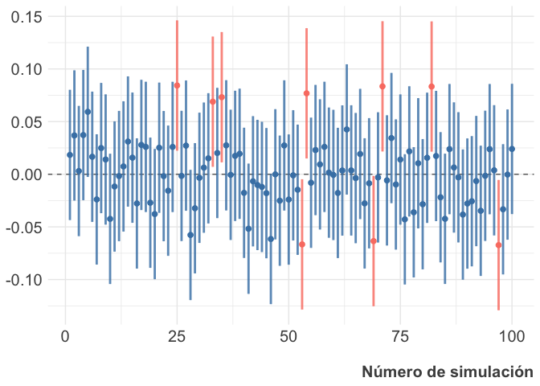

```r
# FIJAMOS LA SEMILLA QUE DICE SEGASI
set.seed(4)

# Paso 3 - Calcular el error estándar de la media muestral, asumiendo
# que el tamaño de la muestra es 1,000
error_est_con_datos_pob <- sd(datos$valores)/sqrt(tamaño_muestra)

# Paso 4 - Calcular la media de cada muestra y construye su respectivo
# intervalo de confianza usando el error estándar que calculamos
# en el paso 3
set.seed(4)
datos %>%
  rep_sample_n(size = tamaño_muestra,
               replace = T,
               reps = numero_muestras) %>%
  summarise(media_muestral = mean(valores),
            lim_sup = media_muestral + 1.96*error_est_con_datos_pob,
            lim_inf = media_muestral - 1.96*error_est_con_datos_pob) %>%
  mutate(color_intervalos = ifelse(lim_sup < 0 | lim_inf > 0,
                                   "salmon", "steelblue")) %>%
  ggplot(aes(x = replicate, y = media_muestral, color = color_intervalos)) +
  geom_hline(yintercept = 0, color = "grey40", linetype = 2, size = 0.5) +
  geom_point(size = 2) +
  geom_errorbar(aes(ymin = lim_inf, ymax = lim_sup), width = 0.01,
                alpha = 0.82, size = 1) +
  scale_color_manual(values = c("salmon", "steelblue")) +
  labs(x = "\nNúmero de simulación") +
  theme_minimal() +
  theme(axis.title.x = element_text(hjust = 1, face = "bold",
                                    color = "grey30", size = 15),
        axis.title.y = element_blank(),
        axis.text = element_text(size = 15),
        legend.position = "none")
```

> No, R no se equivocó. Lo que pasa es que, por probabilidad, es posible que de los primeros 100 Intervalos de Confianza simulados, haya más de 5 en los que no cae el parámetro poblacional. Sin embargo, si replicamos este modelo un número muy grande de veces, la poporción de intervalos que acaparen el parámetro poblacional efectivamente va a tender al 95 %.
4. Partiendo del código que tienes arriba, ajusta el código para (i) aumentar el número de muestras a **10,000**; (ii) calcular la proporción de intervalos de confianza generados con estas muestras que incluyen al parámetro poblacional. **NO TIENES QUE GRAFICAR LOS 100K INTERVALOS DE CONFIANZA**.

```r
# Paso 1 - Generar los datos poblacionales
set.seed(33)
datos <-
  tibble(valores = rnorm(n = 1e6, mean = 0, sd = 1))

# Paso 2 - Definir el tamaño de cada muestra y el número de muestras
tamaño_muestra <- 1000
numero_muestras <- 10000

# Paso 3 - Calcular el error estándar de la media muestral, asumiendo
# que el tamaño de la muestra es 1,000
error_est_con_datos_pob <- sd(datos$valores)/sqrt(tamaño_muestra)

# Paso 4 - Calcular la media de cada muestra y construye su respectivo
# intervalo de confianza usando el error estándar que calculamos
# en el paso 3
set.seed(4)
datos %>%
  rep_sample_n(size = tamaño_muestra,
               replace = T,
               reps = numero_muestras) %>%
  summarise(media_muestral = mean(valores),
            lim_sup = media_muestral + 1.96*error_est_con_datos_pob,
            lim_inf = media_muestral - 1.96*error_est_con_datos_pob) %>%
  summarise(intervalo_incluye = sum(ifelse(lim_sup < 0 | lim_inf > 0, 0, 1))) %>%
  mutate(prop_incluye = intervalo_incluye/numero_muestras)
```

```
## # A tibble: 1 x 2
##   intervalo_incluye prop_incluye
##               <dbl>        <dbl>
## 1              9488       0.9488
```

> Como podemos ver acá, ya ahora si la proporción de intervalos se aproxima al 95 %.

# Ejercicio 3

En el paso 3 del ejercicio anterior usé la desviación estándar de la variable poblacional (misma que en el paso 1 definimos como `sd = 1`) para calcular el error estándar de la distribución muestral de la media.

En la vida real, es muy poco probable que conozcamos la desviación estándar de la variable poblacional, así que en este ejercicio asumiremos que no la conocemos.

Por favor calcula el **error estándar de la distribución muestral de la media** usando la estimación de la desviación estándar de la variable poblacional con los datos de **100** muestras. Guardarás el resultado de este cálculo en una variable llamada `error_est_datos_muestra`.

**OJO:** Dado que debes estimar la desviación estándar de la variable poblacional con los datos de cada muestra por separado, al final del ejercicio deberás tener un tibble con 100 renglones (uno por muestra) y tres columnas: `replicate`, `media_muestral` y `error_est_datos_muestra`.

```r
# Paso 1 - Generar los datos poblacionales
set.seed(33)
datos <-
  tibble(valores = rnorm(n = 1e6, mean = 0, sd = 1))

# Paso 2 - Definir el tamaño de cada muestra y el número de muestras
tamaño_muestra <- 1000
numero_muestras <- 100

# Paso 3 - Calcular la media de cada muestra y el error estándar de la media muestral, estimando la desviación estándar de la variable poblacional.

set.seed(4)
datos %>%
  rep_sample_n(size = tamaño_muestra,
               replace = T,
               reps = numero_muestras) %>%
  summarise(media_muestral = mean(valores),
            error_est_datos_muestra = sd(valores)/sqrt(tamaño_muestra))
```

```
## # A tibble: 100 x 3
##    replicate media_muestral error_est_datos_muestra
##        <int>          <dbl>                   <dbl>
##  1         1    0.01835448               0.03142291
##  2         2    0.03685524               0.03065791
##  3         3    0.003059765              0.03218418
##  4         4    0.03721368               0.03173951
##  5         5    0.05931238               0.03180650
##  6         6    0.01661044               0.03241960
##  7         7   -0.02390758               0.03190266
##  8         8    0.02488777               0.03060030
##  9         9    0.01402477               0.03225584
## 10        10   -0.04237659               0.03127836
## # … with 90 more rows
```

1. ¿Los valores en la columna `error_est_datos_muestra` todos iguales? ¿Esto está bien o es señal de que hay un problema?

> Los errores estándar de los datos de la muestra son todos distintos, porque es un error estándar por cada una de las estimaciones de la media de la muestra varía para cada muestra diferente.
2. ¿Los valores en la columna `error_est_datos_muestra` son exactamente iguales al valor que obtuvimos en el paso 3 del ejercicio anterior? ¿Esto está bien o es señal de que hay un problema?

> No son iguales (aunque si muy similares), ya que el error estándar del ejercicio 3 se calculó con el valor de la desviación estándar de todos los datos de la población, mientras que el error estándar calculado en este ejercicio se realizó con la estimación muestral de esta desviación estándar.

# Ejercicio 4

Repasemos la diferencia entre error **muestral** y error **estándar**. Para ello usaremos los datos de una distribución **gamma**. En [esta](https://onlinelibrary.wiley.com/doi/pdf/10.1002/9781119197096.app03) (p. 910) y [esta liga](http://wiki.stat.ucla.edu/socr/index.php/AP_Statistics_Curriculum_2007_Gamma) encontrarás más detalles sobre esta distribución.

1. Usa el siguiente código para construir la distribución:

```r
datos <- tibble(valores = rgamma(n = 1e5, shape = 2, scale = 1))
```

2. Toma **100** muestras aleatorias de tamaño **120**, calcula la media de cada muestra y el o los error(es) muestral(es)

```r
datos %>%
  rep_sample_n(size = 120, reps = 100) %>%
# Calculamos la media de cada muestra
  summarise(media_muestral = mean(valores)) %>%
# Calculamos el error muestral de cada muestra con el Par. Pob.
  mutate(error_muestral = media_muestral - mean(datos$valores))
```

```
## # A tibble: 100 x 3
##    replicate media_muestral error_muestral
##        <int>          <dbl>          <dbl>
##  1         1       1.995074    0.004581609
##  2         2       1.912890   -0.07760184
##  3         3       2.076706    0.08621392
##  4         4       1.865318   -0.1251737
##  5         5       1.732433   -0.2580587
##  6         6       1.922717   -0.06777534
##  7         7       2.043008    0.05251626
##  8         8       2.016195    0.02570304
##  9         9       2.123461    0.1329694
## 10        10       2.241213    0.2507209
## # … with 90 more rows
```

3. Toma **100** muestras aleatorias de tamaño **120**, calcula la media de cada muestra y el o los error(es) estándar.

```r
datos %>%
  rep_sample_n(size = 120, reps = 100) %>%
  summarise(media_muestral = mean(valores),
            error_estandar_media_muestral = sd(valores)/sqrt(120)) %>%
  summarise(error_estandar = sd(media_muestral))
```

```
## # A tibble: 1 x 1
##   error_estandar
##            <dbl>
## 1      0.1122577
```

# Ejercicio 5

Basta de simulaciones. Bueno, casi. En este ejercicio tendrás que seguir el caminito lleno de incertidumbre de toda persona que trata de entender las características de una población a partir de una muestra.

1. Asume que **67%** de la población de México está a favor del paro nacional del 9 de marzo “Un día sin mujeres” ([liga](https://elfinanciero.com.mx/nacional/57-de-las-mujeres-piensan-sumarse-al-paro-nacional)) y el **33%** restante está en contra. Construye una población hipotética de **1 millón** de personas con estas proporciones. Puedes representar a los que están a favor del paro con un **1** y a los que están en contra con un **0**.
2. Olvida que sabes las proporciones poblacionales.
3. Planta un `set.seed(1)` y toma **una** sola muestra de tamaño **500**.
4. Usando los datos de tu muestra, estima la proporción de personas que está a favor del paro.
5. Usando los datos de tu muestra, construye un intervalo de confianza de 99%.
6. Reporta los resultados mostrando la/el pro que eres.

**Muestra de tamaño 500**

```r
poblacion <- tibble(preferencia = c(rep(1, 670000), rep(0, 330000)))

tamaño_muestra <-  500

# Mi propuesta :3
poblacion %>%
  rep_sample_n(size = tamaño_muestra, reps = 1) %>%
  summarise(proporcion_muestral = mean(preferencia),
            EE = sd(preferencia)/sqrt(tamaño_muestra)) %>%
  mutate(lim_inf = proporcion_muestral - 2.58*EE,
         lim_sup = proporcion_muestral + 2.58*EE,
         mult = 2.58*EE)
```

```
## # A tibble: 1 x 6
##   replicate proporcion_muestral         EE   lim_inf   lim_sup       mult
##       <int>               <dbl>      <dbl>     <dbl>     <dbl>      <dbl>
## 1         1             0.68800 0.02074060 0.6344893 0.7415107 0.05351074
```

**Muestra de tamaño 100**

```r
poblacion <- tibble(preferencia = c(rep(1, 670000), rep(0, 330000)))

tamaño_muestra <-  100

# Mi propuesta :3
poblacion %>%
  rep_sample_n(size = tamaño_muestra, reps = 1) %>%
  summarise(proporcion_muestral = mean(preferencia),
            EE = sd(preferencia)/sqrt(tamaño_muestra)) %>%
  mutate(lim_inf = proporcion_muestral - 2.58*EE,
         lim_sup = proporcion_muestral + 2.58*EE)
```

```
## # A tibble: 1 x 5
##   replicate proporcion_muestral         EE   lim_inf   lim_sup
##       <int>               <dbl>      <dbl>     <dbl>     <dbl>
## 1         1                0.52 0.05021167 0.3904539 0.6495461
```

**Muestra de tamaño 1,000**

```r
poblacion <- tibble(preferencia = c(rep(1, 670000), rep(0, 330000)))

tamaño_muestra <-  1000

# Mi propuesta :3
poblacion %>%
  rep_sample_n(size = tamaño_muestra, reps = 1) %>%
  summarise(proporcion_muestral = mean(preferencia),
            EE = sd(preferencia)/sqrt(tamaño_muestra)) %>%
  mutate(lim_inf = proporcion_muestral - 2.58*EE,
         lim_sup = proporcion_muestral + 2.58*EE)
```

```
## # A tibble: 1 x 5
##   replicate proporcion_muestral         EE   lim_inf   lim_sup
##       <int>               <dbl>      <dbl>     <dbl>     <dbl>
## 1         1             0.69700 0.01453968 0.6594876 0.7345124
```

**R:** A medida en que el tamaño de la muestra va creciendo, el intervalo de confianza se va volviendo más angosto.

[^1]: En esta segunda liga basta con que leas los primeros dos párrafos, pero todo el post vale la pena.